# *Pseudonitzschia* and its parasitoids

Global scale co-occurrence analysis

Lucia Campese

September 2020

### Aim

The aim is to explore the *in silico* association between *Pseudonitzschia* and its known eukaryotic parasitoids through a host-parasite network using Tara Oceans data.

### Dataset

##### Data: TARA Oceans and TARA Oceans Polar circle metabarcording (V4)

##### Taxa: *Pseudonitzschia*, Fungi, Oomycetes

##### Geographic scale: Global

#### **Preparing datasets**

##### 1. *Pseudonitzschia*

The used dataset is made of **324** different **sequences** assigned to *Pseudonitzschia* species with a **100% identity** to MareChiara database (curated by Valeria Ruggiero) and occurring in at least **3 sampling stations** in the TARA Oceans dataset (see [here](https://htmlpreview.github.io/?https://github.com/Iucia/Pseudonitzschia/blob/master/comparison100identity.html) for details on dataset building).

```r
library(data.table)
library(tidyverse)

Pn_candi_identity100.distr <- fread("C:/Users/Userszn/Documents/PhD/script/Pseudonitzschia/metaB/V4/cfr100pid/18S_V4_1191_samples_Pncandi_3readsmin_pid100.distr")

colnames(Pn_candi_identity100.distr) <- c("seqId", "sample", "readcounts")

paste0(n_distinct(Pn_candi_identity100.distr$seqId), " Pseudonitzschia sequence Ids")
```

```
## [1] "324 Pseudonitzschia sequence Ids"
```

```r
Pn_candi_identity100.tax <- fread("C:/Users/Userszn/Documents/PhD/script/Pseudonitzschia/metaB/V4/cfr100pid/Pn_tara_candi_final_pid100.txt") %>%
  separate(V1, into = c("seqId", "size"), sep = ";") %>%
  rename(tax = V2, pid = V3) %>%
  select(seqId, tax, pid)

#subset tax (still with 508 seq) using the distr file (with the corret 324 seq) {the aim is to add the taxonomy info}

Pn_candi_identity100.distr.tax <- inner_join(Pn_candi_identity100.tax, Pn_candi_identity100.distr, by = "seqId")

##add env

env <- fread("C:/Users/Userszn/Documents/PhD/script/Pseudonitzschia/metaB/V4/18S_V4_1191_samples_context.tsv")

Pn_candi_identity100.distr.tax.env <- inner_join(Pn_candi_identity100.distr.tax, env) %>%
  select(seqId:readcounts,Pangaea_id:minimum.generation.time.h)


final_tara_mc <- Pn_candi_identity100.distr.tax.env %>%
  mutate(species = case_when(grepl("allochrona", tax) ~ "allochrona",
                             grepl("americana", tax) ~ "ID2_amer|cacia|circump|granii",
                             grepl("arenysensis", tax) ~ "ID1_aren|dolo|arc|subcur",
                             grepl("ID3_P._australis", tax) ~ "ID3_australis|multiseries",
                             grepl("P._australis_SPC21", tax) ~ "australis_single",
                             grepl("batesiana", tax) ~ "batesiana",
                             grepl("brasiliana", tax) ~ "ID4_brasiliana|lineola",
                             grepl("calliantha", tax) ~ "calliantha",
                             grepl("cuspidata", tax) ~ "cuspidata",
                             grepl("decipiens", tax) ~ "decipiens",
                             grepl("delicatissima", tax) ~ "delicatissima",
                             grepl("fraudulenta", tax) ~ "fraudulenta",
                             grepl("fukuyoi", tax) ~ "fukuyoi",
                             grepl("galaxiae", tax) ~ "galaxiae",
                             grepl("heimii", tax) ~ "heimii",
                             grepl("kodamae", tax) ~ "ID5_kodamae|lundholmiae",
                             grepl("mannii", tax) ~ "mannii",
                             grepl("micropora", tax) ~ "micropora",
                             grepl("P._multiseries_NparI", tax) ~ "multiseries_single",
                             grepl("multistriata", tax) ~ "multistriata",
                             grepl("pseudodelicatissima", tax) ~ "pseudodelicatissima",
                             grepl("pungens", tax) ~ "pungens",
                             grepl("sabit", tax) ~ "sabit",
                             grepl("turgidula", tax) ~ "turgidula",
                            TRUE ~ "ERRORE")) %>%
  mutate(length = "tobedone") %>%
  select(seqId, length, species, sample, readcounts, Station.label:Depth.chloro.max) %>%
  mutate(dataset = c("TARA-MC"))
```

##### 2. Oomycetes

```bash
#1. Extract Peronosporomycetes  sequences from the the V4

srun cat 18S_V4_1191_samples.results | grep Peronosporomycetes  > 18S_V4_1191_samples_oomyc.results &


#take only sequences with at least 3 reads (seen three times in the whole dataset) [*]
srun awk '$2>2' 18S_V4_1191_samples_oomyc.results > 18S_V4_1191_samples_oomyc_3readsmin.results &

#wc -l 5403 18S_V4_1191_samples_oomyc.results
#wc -l 4451 18S_V4_1191_samples_oomyc_3readsmin.results

#[*]as adviced by Nicholas Henry.


#Extract only seq ids (column 1)
awk '{print $1}' 18S_V4_1191_samples_oomyc_3readsmin.results > 18S_V4_1191_samples_oomyc_3readsmin_seqid.txt

#wc -l: 4451 18S_V4_1191_samples_oomyc_3readsmin_seqid.txt


#use the retrieved 4451 sequence Ids to subset the distr file (i.e. the one
#containing seqId|sampleId|readcounts

srun grep -Ff 18S_V4_1191_samples_oomyc_3readsmin_seqid.txt ~/Data/metaB/V4/18S_V4_1191_samples.distr > 18S_V4_1191_samples_oomyc_3readsmin.distr &
```

```r
library(data.table)
library(tidyverse)

oomyc.distr <- fread("C:/Users/Userszn/Documents/PhD/script/Pseudonitzschia/metaB/V4/Parasites/Oomiceti/18S_V4_1191_samples_oomyc_3readsmin.distr")


oomyc.tax <- fread("C:/Users/Userszn/Documents/PhD/script/Pseudonitzschia/metaB/V4/Parasites/Oomiceti/18S_V4_1191_samples_oomyc_3readsmin.results", header = F, sep = "\t") #17 sequences


colnames(oomyc.distr) <- c("seqId", "sample", "readcounts")
colnames(oomyc.tax) <- c("seqId", "totreads", "perc.identity", "lineage", "idpr2")

#oomyc.tax %>%
  #splitstackshape::cSplit("lineage", "|")

oomyc.distr.tax <- inner_join(oomyc.distr, oomyc.tax, by = "seqId") %>%
  select(-totreads)

env <- fread("C:/Users/Userszn/Documents/PhD/script/Pseudonitzschia/metaB/V4/18S_V4_1191_samples_context.tsv")

oomyc.distr.tax.env <- inner_join(oomyc.distr.tax, env)


##filter on occurrence

oomyc.distr.tax.env.filtered <- oomyc.distr.tax.env %>%
  group_by(seqId) %>%
  mutate(Occurrence = n_distinct(Station.label)) %>%
  ungroup() %>%
  filter(Occurrence > 1)

oomyc.distr.tax.env1 <- oomyc.distr.tax.env.filtered %>%
  select(seqId, lineage, perc.identity, sample, readcounts, Station.label:Depth.chloro.max)


#oomyc.distr.tax.env1 is the final file with seqIds, taxonomical annotation, distribution and environmental info


paste0(n_distinct(oomyc.distr.tax.env1$seqId), " Oomycetes sequences")
```

```
## [1] "2997 Oomycetes sequences"
```

```r
oomyc_3reads2stationsmin_seqid <- oomyc.distr.tax.env1 %>%
  select(seqId) %>%
  unique()

write.csv(oomyc_3reads2stationsmin_seqid, "oomyc_3reads2stationsmin_seqid.csv", row.names = F)


###levo il nome della colonna su excel e esporto il file come txt file e lo porto su falkor
```

```r
###FALKOR
###take fastas

#wc -l 2997 oomyc_3reads2stationsmin_seqid.txt

##convert file (ascii with crlf terminators) into a simple ascii file, in order to be grepped with the fasta file (simple ascii):

cat oomyc_3reads2stationsmin_seqid.txt | tr -d '\r' > oomyc_3reads2stationsmin_seqid_ascii.txt

#use seqIds to retrieve fasta of the sequences

srun grep -w -A 1 -Ff oomyc_3reads2stationsmin_seqid_ascii.txt ~/Data/metaB/V4/18S_V4_1191_samples.fas --no-group-separator > 18S_V4_1191_samples_oomyc_3reads2stationsmin.fas &

#check if it retrieved the right number of sequences

grep ">" 18S_V4_1191_samples_oomyc_3reads2stationsmin.fas -c
#2997

wc -l oomyc_3reads2stationsmin_seqid_ascii.txt
#2997

#ok.

##I now have both the fasta: 18S_V4_1191_samples_oomyc_3reads2stationsmin.fas
##and the table with taxonomy, env.par etc: oomyc.distr.tax.env1
```

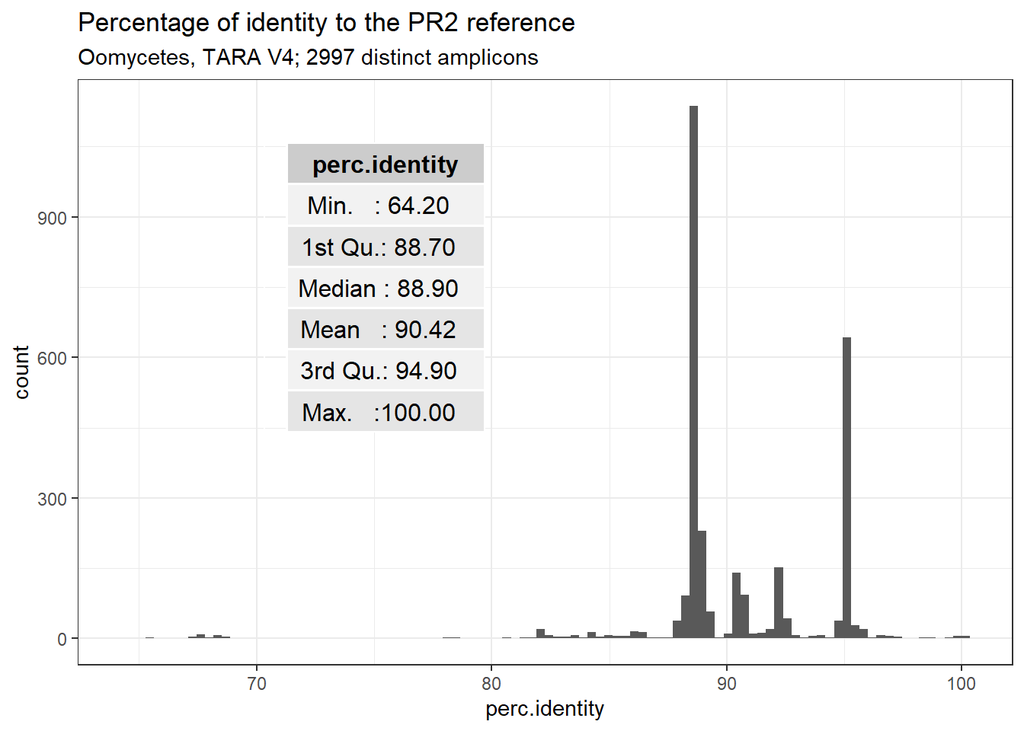

```r
oomyc_percid <- oomyc.distr.tax.env1 %>%
  select(seqId, perc.identity) %>%
  unique() %>%
  select(perc.identity) %>%
  summary()


oomyc.distr.tax.env1 %>%
 group_by(seqId) %>%
  mutate(totreads = sum(readcounts)) %>%
  ungroup() %>%
  select(seqId, perc.identity, totreads) %>%
  unique() %>%
  ggplot +
  aes(x = perc.identity,
      fill = totreads) +
  geom_histogram(bins = 100) +
  theme_bw() +
  annotation_custom(gridExtra::tableGrob(oomyc_percid), xmin=70, xmax=80, ymin=600, ymax=900) +
  ggtitle("Percentage of identity to the PR2 reference",
          subtitle= paste0("Oomycetes, TARA V4; ",
                           n_distinct(oomyc.distr.tax.env1$seqId),
                           " distinct amplicons"))
```

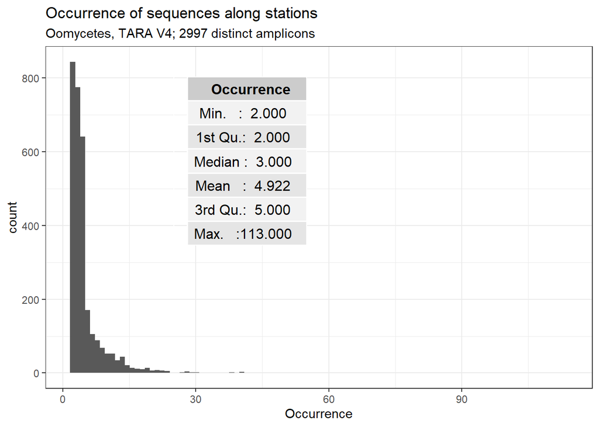

```r
oomyc.occurrences <- oomyc.distr.tax.env1 %>%
  group_by(seqId) %>%
  summarise(Occurrence = n_distinct(Station.label)) %>%
  arrange(Occurrence)

oomyc.table_occurrences <- oomyc.occurrences %>%
  select(Occurrence) %>%
  summary()

oomyc.occurrences %>%
  ggplot() +
  aes(x=Occurrence) +
  geom_histogram(bins = 100) +
  theme_bw() +
  annotation_custom(gridExtra::tableGrob(oomyc.table_occurrences), xmin=25, xmax=55, ymin=400, ymax=750) +
  ggtitle("Occurrence of sequences along stations",
          subtitle= paste0("Oomycetes, TARA V4; ",
                           n_distinct(oomyc.occurrences$seqId),
                           " distinct amplicons"))
```

```r
library(maps)

world_map <- map_data("world")
p <- ggplot() + coord_fixed()

base_world3 <- p + geom_polygon(data=world_map,aes(x=long, y=lat,group=group),colour="gray80",size=0.2, fill="gray80")+
  theme_bw() + coord_fixed()


#map
oomyc.map <- oomyc.distr.tax.env1 %>%
  group_by(Station.label) %>%
  mutate(Lat= mean(Latitude),
         Long=mean(Longitude),
         abundance.per.station = sum(readcounts),
         richness.per.station.amplicons = n_distinct(seqId)) %>%
  ungroup() %>%
  select(seqId, Station.label, Lat, Long, abundance.per.station,
         richness.per.station.amplicons) %>% unique()

base_world3+
  geom_point(data=oomyc.map,
             aes(x = Long, y = Lat,
                 size = abundance.per.station,
                 fill = richness.per.station.amplicons),
             pch = 21, col = "black") +
  scale_fill_viridis_c() +
  theme_minimal() +
  theme(legend.text=element_text(size=10)) +
  ggtitle("Oomycetes abundance and richness per station (V4)", "")


####map
fungi.map <- Fungi.distr.tax.env1 %>%
  group_by(Station.label) %>%
  mutate(Lat= mean(Latitude),
         Long=mean(Longitude),
         abundance.per.station = sum(readcounts),
         richness.per.station.amplicons = n_distinct(seqId)) %>%
  ungroup() %>%
  select(seqId, Station.label, Lat, Long, abundance.per.station,
         richness.per.station.amplicons) %>% unique()

base_world3+
  geom_point(data=fungi.map,
             aes(x = Long, y = Lat,
                 size = abundance.per.station,
                 fill = richness.per.station.amplicons),
             pch = 21, col = "black") +
  scale_fill_viridis_c() +
  theme_minimal() +
  theme(legend.text=element_text(size=10)) +
  ggtitle("Fungi abundance and richness per station (V4)", "")






tbm_pseudonitzschia <- final_tara_mc %>%
  select(seqId, sample:Depth.chloro.max) %>%
  mutate(taxogroup = "Pseudonitzschia")

tbm_fungi <- Fungi.distr.tax.env1 %>%
  select(seqId, sample:Depth.chloro.max) %>%
  mutate(taxogroup = "Fungi")

tbm_oomyc <- oomyc.distr.tax.env1 %>%
  select(seqId, sample:Depth.chloro.max) %>%
  mutate(taxogroup = "Oomycetes")



pn_oomyc_fungi.map <- rbind(tbm_pseudonitzschia, tbm_oomyc, tbm_fungi) %>%
  group_by(Station.label) %>%
  mutate(Lat= mean(Latitude),
         Long=mean(Longitude)) %>%
  ungroup() %>%
  group_by(Station.label, taxogroup) %>%
  mutate(abundance.per.station = sum(readcounts),
         richness.per.station.amplicons = n_distinct(seqId)) %>%
  ungroup() %>%
  select(seqId, Station.label, Lat, Long, abundance.per.station,
         richness.per.station.amplicons, taxogroup) %>% unique()

base_world3+
  geom_point(data=pn_oomyc_fungi.map,
             aes(x = Long, y = Lat,
                 size = abundance.per.station,
                 fill = taxogroup),
             pch = 21, col = "black") +
  #scale_fill_viridis_c() +
  theme_minimal() +
  theme(legend.text=element_text(size=10)) +
  ggtitle("Abundance and richness per station (V4)", "")
```

[output not shown]

##### 3. Fungi

```r
library(data.table)
library(tidyverse)

Fungi.distr <- fread("C:/Users/Userszn/Documents/PhD/script/Pseudonitzschia/metaB/V4/Parasites/Fungi/18S_V4_1191_samples_Fungi_3readsmin.distr")

Fungi.tax <- fread("C:/Users/Userszn/Documents/PhD/script/Pseudonitzschia/metaB/V4/Parasites/Fungi/18S_V4_1191_samples_Fungi_3readsmin.results", header = F, sep = "\t") #17 sequences


colnames(Fungi.distr) <- c("seqId", "sample", "readcounts")
colnames(Fungi.tax) <- c("seqId", "totreads", "perc.identity", "lineage", "idpr2")


#Fungi.tax %>%
#  splitstackshape::cSplit("lineage", "|") %>%
#  filter(lineage_06 != "Fungi")

##checked sono tutti funghi


Fungi.distr.tax <- inner_join(Fungi.distr, Fungi.tax, by = "seqId") %>%
  select(-totreads)


env <- fread("C:/Users/Userszn/Documents/PhD/script/Pseudonitzschia/metaB/V4/18S_V4_1191_samples_context.tsv")

Fungi.distr.tax.env <- inner_join(Fungi.distr.tax, env)


##filter on occurrence

Fungi.distr.tax.env.filtered <- Fungi.distr.tax.env %>%
  group_by(seqId) %>%
  mutate(Occurrence = n_distinct(Station.label)) %>%
  ungroup() %>%
  filter(Occurrence > 1)

Fungi.distr.tax.env1 <- Fungi.distr.tax.env.filtered %>%
  select(seqId, lineage, perc.identity, sample, readcounts, Station.label:Depth.chloro.max)


#Fungi.distr.tax.env1 is the final file with seqIds, taxonomical annotation, distribution and environmental info


paste0(n_distinct(Fungi.distr.tax.env1$seqId), " Fungi sequences")
```

```
## [1] "34523 Fungi sequences"
```

```r
Fungi_3reads2stationsmin_seqid <- Fungi.distr.tax.env1 %>%
  select(seqId) %>%
  unique()

write.csv(Fungi_3reads2stationsmin_seqid, "Fungi_3reads2stationsmin_seqid.csv", row.names = F)


###levo il nome della colonna su excel e esporto il file come txt file e lo porto su falkor
```

```r
###FALKOR
###take fastas

#wc -l 34523 Fungi_3reads2stationsmin_seqid.txt

##convert file (ascii with crlf terminators) into a simple ascii file, in order to be grepped with the fasta file (simple ascii):

cat Fungi_3reads2stationsmin_seqid.txt | tr -d '\r' > Fungi_3reads2stationsmin_seqid_ascii.txt

#use seqIds  to retrieve fasta of the sequences
srun grep -w -A 1 -Ff Symbionts/Fungi_3reads2stationsmin_seqid_ascii.txt 18S_V4_1191_samples.fas --no-group-separator > 18S_V4_1191_samples_Fungi_3reads2stationsmin.fas &

#check if it retrieved the right number of sequences

grep ">" 18S_V4_1191_samples_Fungi_3reads2stationsmin.fas -c
#34523
wc -l Fungi_3reads2stationsmin_seqid_ascii.txt
#34523

#ok.

##I now have both the fasta: 18S_V4_1191_samples_Fungi_3reads2stationsmin.fas
##and the table with taxonomy, env.par etc: Fungi.distr.tax.env1
```

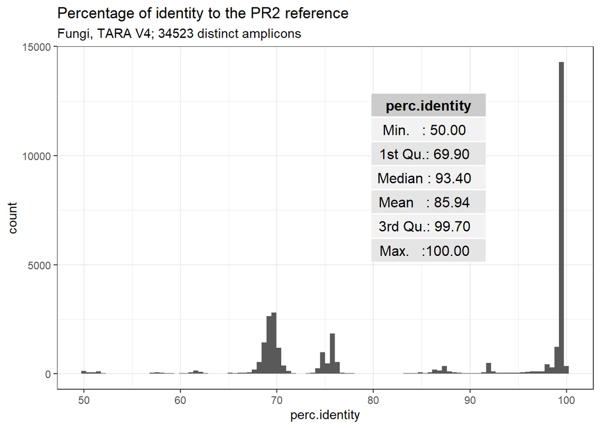

```r
Fungi_percid <- Fungi.distr.tax.env1 %>%
  select(seqId,perc.identity) %>%
  unique() %>%
  select(perc.identity) %>%
  summary()



Fungi.distr.tax.env1 %>%
  group_by(seqId) %>%
  mutate(totreads = sum(readcounts)) %>%
  ungroup() %>%
  select(seqId, perc.identity, totreads) %>%
  unique() %>%
  ggplot +
  aes(x = perc.identity,
      fill = totreads) +
  geom_histogram(bins = 100) +
  theme_bw() +
  # xlim(90,100) +
  annotation_custom(gridExtra::tableGrob(Fungi_percid), xmin=80, xmax=90, ymin=6000, ymax=12000) +
  ggtitle("Percentage of identity to the PR2 reference",
          subtitle= paste0("Fungi, TARA V4; ",
                           n_distinct(Fungi.distr.tax.env1$seqId),
                           " distinct amplicons"))
```

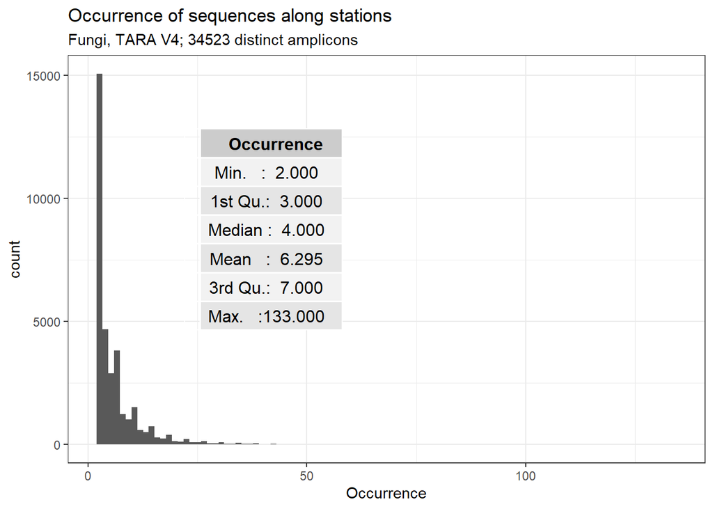

```r
Fungi.occurrences <- Fungi.distr.tax.env1 %>%
  group_by(seqId) %>%
  summarise(Occurrence = n_distinct(Station.label)) %>%
  arrange(Occurrence)


fungi.table_occurrences <- Fungi.occurrences %>%
  select(Occurrence) %>%
  summary()


Fungi.occurrences %>%
  ggplot() +
  aes(x=Occurrence) +
  geom_histogram(bins = 100) +
  theme_bw() +
  annotation_custom(gridExtra::tableGrob(fungi.table_occurrences), xmin=25, xmax=55, ymin=7500, ymax=10000) +
  ggtitle("Occurrence of sequences along stations",
          subtitle= paste0("Fungi, TARA V4; ",
                           n_distinct(Fungi.occurrences$seqId),
                           " distinct amplicons"))
```

The dataset is then split into two groups according on the percentage of identity (pid) to the PR2 database:

1. group of sequences with pid $\geqslant$ 80
2. group of sequences with pid < 80

```r
Fungi.distr.tax.env1.pidgr <- Fungi.distr.tax.env1 %>%
  mutate(pid.group = case_when(perc.identity >= 80 ~ "high.pid",
                               perc.identity < 80 ~ "low.pid"))


Fungi.split <- split(Fungi.distr.tax.env1.pidgr, Fungi.distr.tax.env1.pidgr$pid.group)
list2env(Fungi.split, .GlobalEnv)
```

```
## <environment: R_GlobalEnv>
```

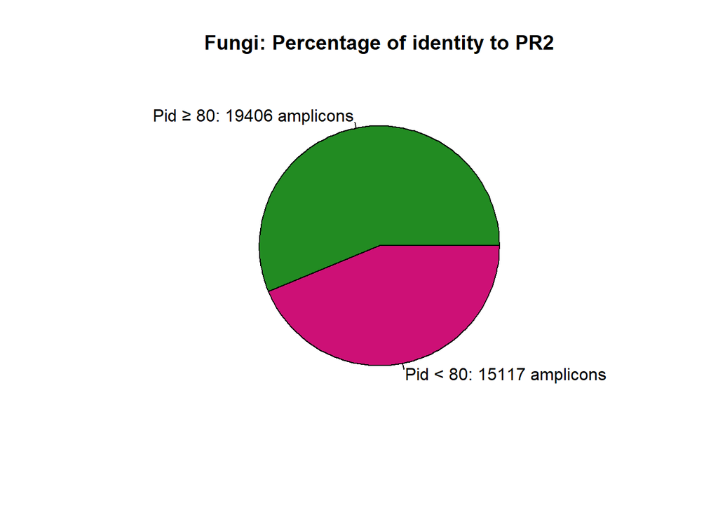

```r
Fungi.distr.tax.env1.pidgr.annot <- Fungi.distr.tax.env1.pidgr %>%
  group_by(pid.group) %>%
  summarise(amount = n_distinct(seqId)) %>%
  ungroup()

pie(Fungi.distr.tax.env1.pidgr.annot$amount,
labels = c(paste0("Pid \u2265 80: ", n_distinct(high.pid$seqId), " amplicons"),
           paste0("Pid < 80: ", n_distinct(low.pid$seqId), " amplicons")),
  col=c("forestgreen", "deeppink3"),
  main = "Fungi: Percentage of identity to PR2")
```

```r
n_distinct(high.pid$seqId) + n_distinct(low.pid$seqId) == n_distinct(Fungi.distr.tax.env1$seqId)
```

```
## [1] TRUE
```

The sequences in fasta format are then extracterd for the high percentage group and blasted against a cleaned reference database of dinoflagellates.

```r
fungi.high.pid.seqid <- high.pid %>%
  select(seqId) %>%
  unique()

write.csv(fungi.high.pid.seqid, "fungi.high.pid.seqid.csv", row.names = F)

###levo il nome della colonna su excel e esporto il file come txt file e lo porto su falkor

###rsync -avz --progress /drives/c/Users/Userszn/Documents/PhD/Git/bin/Pseudonitzschia/fungi.high.pid.seqid.txt lcampese@193.205.231.59:/home/lcampese/Data/metaB/V4/Parasites/Fungi/
```

```r
###FALKOR
###take fastas

#wc -l fungi.high.pid.seqid.txt: 19406

##convert file (ascii with crlf terminators) into a simple ascii file, in order to be grepped with the fasta file (simple ascii):

cat fungi.high.pid.seqid.txt | tr -d '\r' > fungi.high.pid.seqid.ascii.txt

#use seqIds  to retrieve fasta of the sequences
srun grep -w -A 1 -Ff fungi.high.pid.seqid.ascii.txt /home/lcampese/Data/metaB/V4/18S_V4_1191_samples.fas --no-group-separator > 18S_V4_1191_samples.fungi.high.pid.fas &

#check if it retrieved the right number of sequences

grep ">" 18S_V4_1191_samples.fungi.high.pid.fas -c
#19406
wc -l fungi.high.pid.seqid.ascii.txt
#19406

#ok

##I now have both the fasta: 18S_V4_1191_samples.fungi.high.pid.fas
##and the table with taxonomy, env.par etc: high.pid
```

```r
#Falkor:

#1) Trasformo il dataset Dino in formato database
makeblastdb -in dino.fasta -dbtype nucl -parse_seqids -out dino_db

#3) Blast con max_target_seqs 1 (mi serve solo il best hit)
blastn -db dino_db -perc_identity 97 -query 18S_V4_1191_samples.fungi.high.pid.fas -outfmt 6 -max_target_seqs 1 -num_threads 8 -out fungi.highpid.checkdino.txt &

#output: wc -l: fungi.highpid.checkdino.txt
#1223
```

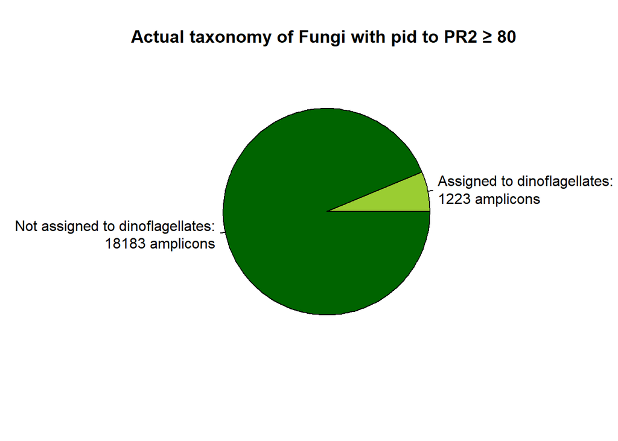

```r
fungi.highpid.checkdino <- fread("C:/Users/Userszn/Documents/PhD/script/Pseudonitzschia/metaB/V4/Parasites/Fungi/fungi.highpid.checkdino.txt", header = F)

fungi.highpid.checkdino_seqIds <- fungi.highpid.checkdino %>%
  select(V1) %>%
  separate(V1, into = c("seqId", "size"), sep = ";") %>%
  select(seqId)


high.pid.annot <- high.pid %>%
  mutate(tax = ifelse(seqId %in% fungi.highpid.checkdino_seqIds$seqId, "dino", "nondino")) %>%
  select(seqId, perc.identity, tax) %>%
  group_by(tax) %>%
  summarise(amount = n_distinct(seqId)) %>%
  ungroup()


pie(high.pid.annot$amount,
labels = c(paste0("Assigned to dinoflagellates:
", n_distinct(fungi.highpid.checkdino_seqIds$seqId), " amplicons"),
                                   paste0("Not assigned to dinoflagellates:
", (n_distinct(high.pid$seqId) - n_distinct(fungi.highpid.checkdino_seqIds$seqId)), " amplicons")),
    col=c("yellowgreen", "darkgreen"),
    main = "Actual taxonomy of Fungi with pid to PR2 \u2265 80 ")
```

The blast results show that 1223 out of the initial 19406 sequences taxonomically assigned to Fungi are actually belonging to dinoflagellates.

The dataset is being cleaned by removing the misassignations and sequences in fasta format are then retrieved.

```r
high.pid.cleaned <- high.pid %>%
  filter(! seqId %in% fungi.highpid.checkdino_seqIds$seqId)


n_distinct(high.pid$seqId) - n_distinct(fungi.highpid.checkdino_seqIds$seqId) == n_distinct(high.pid.cleaned$seqId)
```

```
## [1] TRUE
```

```r
high.pid.cleaned.seqid <- high.pid.cleaned %>%
  select(seqId) %>%
  unique()

write.csv(high.pid.cleaned.seqid, "high.pid.cleaned.seqid.csv", row.names = F)

###levo il nome della colonna su excel e esporto il file come txt file e lo porto su falkor

###rsync -avz --progress /drives/c/Users/Userszn/Documents/PhD/Git/bin/Pseudonitzschia/high.pid.cleaned.seqid.txt lcampese@193.205.231.59:/home/lcampese/Data/metaB/V4/Parasites/Fungi/
```

```r
###FALKOR
###take fastas

#wc -l high.pid.cleaned.seqid.txt:  18183

##convert file (ascii with crlf terminators) into a simple ascii file, in order to be grepped with the fasta file (simple ascii):

cat high.pid.cleaned.seqid.txt | tr -d '\r' > high.pid.cleaned.seqid.ascii.txt

#use seqIds  to retrieve fasta of the sequences
srun grep -w -A 1 -Ff high.pid.cleaned.seqid.ascii.txt /home/lcampese/Data/metaB/V4/18S_V4_1191_samples.fas --no-group-separator > 18S_V4_1191_samples.fungi.highpid.cleaned.fas &

#check if it retrieved the right number of sequences

grep ">" 18S_V4_1191_samples.fungi.highpid.cleaned.fas -c
#18183
wc -l high.pid.cleaned.seqid.ascii.txt
#18183

#ok

#I now have both the fasta: 18S_V4_1191_samples.fungi.highpid.cleaned.fas
##and the table with taxonomy, env.par etc: high.pid.cleaned
```

The final dataset is made of **18183 sequences** .

Did they include BioMarks sequences in PR2 dataset?

1. Download supplementary material from the paper [Richards et al.,2015](http://dx.doi.org/10.1098/rspb.2015.2243).
2. Check headers:

```r
#Falkor: /home/lcampese/Data/metaB/V4/Parasites/Fungi/BioMarKs
#1) combine the 71 fasta files containing sequences of the 71 OTU clusters of the paper into one single fasta files

cat Cluster* > BioMaRks.fas

#take headers of :
# 18S_V4_1191_samples.fungi.highpid.cleaned.fas
# BioMaRks.fas

cat 18S_V4_1191_samples.fungi.highpid.cleaned.fas | grep "^>" | sort > 18S_V4_1191_samples.fungi.highpid.cleaned.fas.header.txt

cat BioMaRks.fas | grep "^>" | sort > BioMaRks.fas.header.txt

##rsync to local
```

```r
mine <- fread("C:/Users/Userszn/Documents/PhD/script/Pseudonitzschia/metaB/V4/Parasites/Fungi/biomarks/marine_fungi-v1.0/71_OTU_sequence_clusters/18S_V4_1191_samples.fungi.highpid.cleaned.fas.header.txt",
              header = F)

biomarks <- fread("C:/Users/Userszn/Documents/PhD/script/Pseudonitzschia/metaB/V4/Parasites/Fungi/biomarks/marine_fungi-v1.0/71_OTU_sequence_clusters/BioMaRks.fas.header.txt",
                  header = F)



mine2 <- mine %>%
  select(V1) %>%
  separate(V1, into = c("bla", "seqId"), sep = ">") %>%
  select(seqId) %>%
  arrange()


biomarks2 <- biomarks %>%
  separate(V1, into = c("bla", "ble"), sep = ">") %>%
  separate(ble, into = c("seqId", "bli"), sep = "_") %>%
  select(seqId) %>%
  arrange()


inner_join(mine2, biomarks2)
```

```
## Empty data.table (0 rows and 1 cols): seqId
```

There is no overlap between headers

3. Blast?

```r
#Falkor: /home/lcampese/Data/metaB/V4/Parasites/Fungi/BioMarKs

#1) Trasformo il mio dataset PR2 (contenente sequenze di Fungi con perc.identity di almeno 80 e senza le sequenze di Dino) in formato database
makeblastdb -in ~/Data/metaB/V4/Parasites/Fungi/18S_V4_1191_samples.fungi.highpid.cleaned.fas -dbtype nucl -parse_seqids -out 18S_V4_1191_samples.fungi.highpid.cleaned_db

#3) Blast con max_target_seqs 1 (mi serve solo il best hit)
blastn -db 18S_V4_1191_samples.fungi.highpid.cleaned_db -perc_identity 100 -query BioMaRks.fas -outfmt 6 -max_target_seqs 1 -num_threads 8 -out fungi.highpid.cleaned.checkBioMarKs.txt &

#wc -l fungi.highpid.cleaned.checkBioMarKs.txt 45

#che vor dì?
```

To be done:

Let’s look at the low.pid group and check manually if some sequence with a percentage of identity around 75% are actually Fungi